# Observations of Red Wine Quality by Subham Biswas

# Volatile acidity vs citric acid

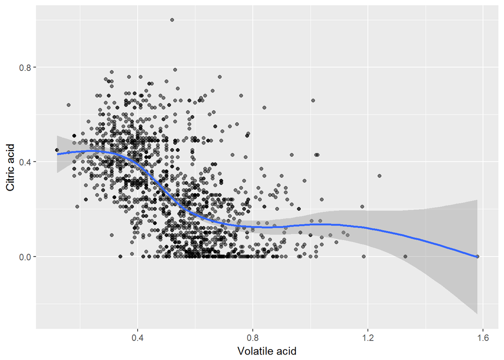

```r
ggplot(red_wine,aes(x = volatile.acidity, y = citric.acid))+
  geom_point(alpha = 0.5)+ geom_smooth(method = 'auto')+
  xlab('Volatile acid')+
  ylab('Citric acid')
```

My original hypothesis was since both are acids they will be positively correlated but according to scatter plot , these variables are negatively correlated.

# Bivariate Analysis

### Talk about some of the relationships you observed in this part of the investigation. How did the feature(s) of interest vary with other features in the dataset?

Volatile acid and alcohol vs quality showed similar behaviour , where rating with average show significant increase while rating with good and bad samples didnot show much which was totally different behaviour as compared to other relations of variables.

### Did you observe any interesting relationships between the other features Ctric acid and Volatile acid are negatively correlated with the coefficient of -0.61025

```r
cor.test(red_wine$volatile.acidity, red_wine$citric.acid, method ='spearman')
```

```
##
##  Spearman's rank correlation rho
##
## data:  red_wine$volatile.acidity and red_wine$citric.acid
## S = 1097200000, p-value < 2.2e-16
## alternative hypothesis: true rho is not equal to 0
## sample estimates:
##        rho
## -0.6102595
```

Because volatile acidity reduces the quality of wine (negative correlation) while citric acid increases wine quality (positive correlation).

### What was the strongest relationship you found?

I found the relation between Fixed acid and Citric acid to be strongest ,with the correlation coefficiet around 0.7 and relation between fixed acid and pH to be highly neative with -0.7 coefficient .

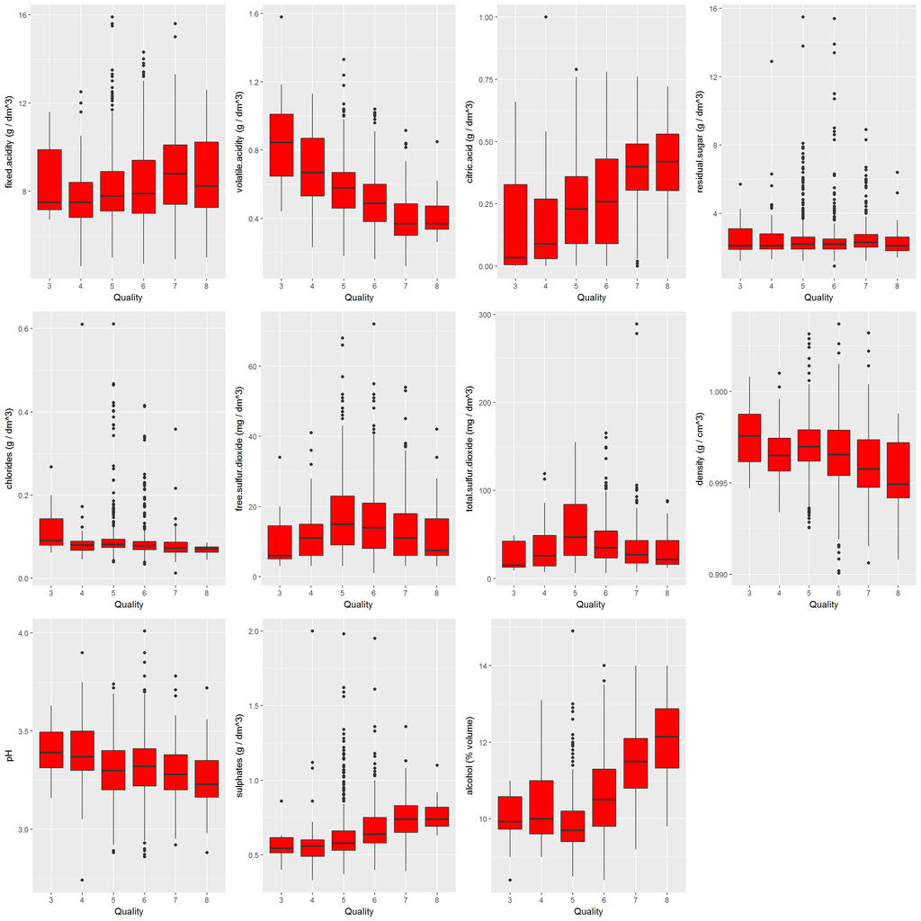

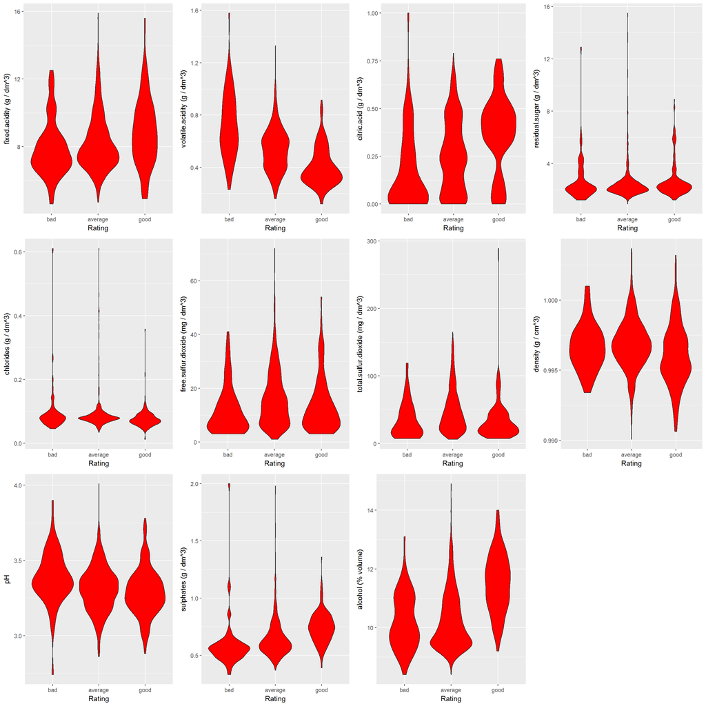